# Exploratory Data Analysis

**30-Year Mortgage Rate**

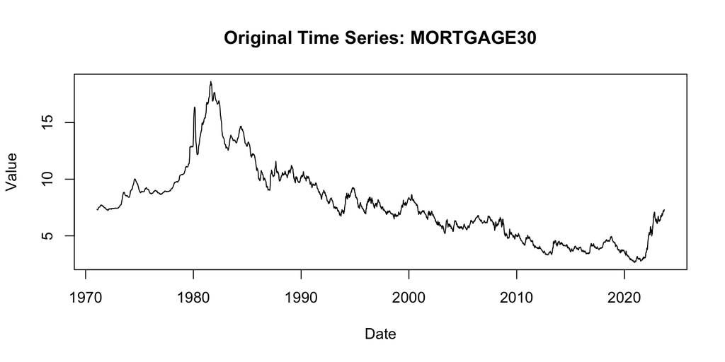

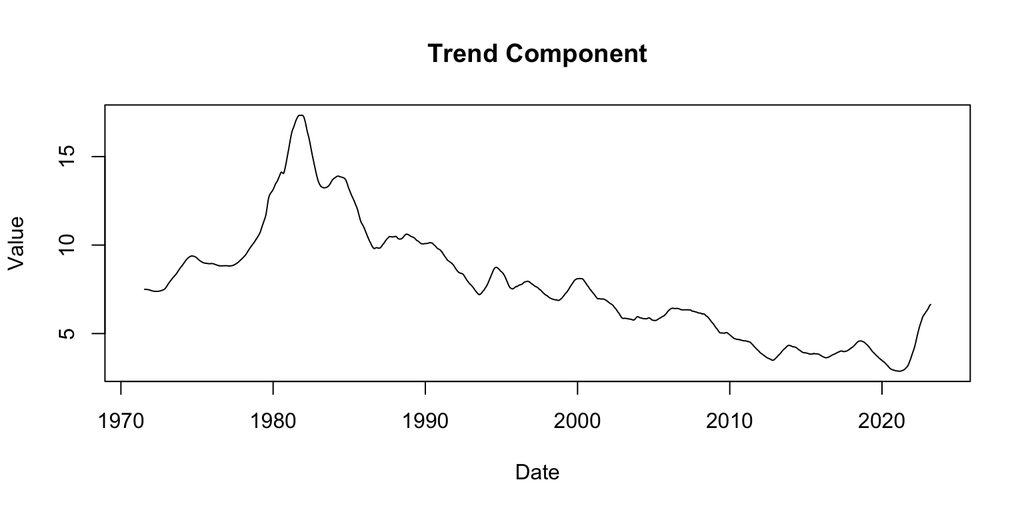

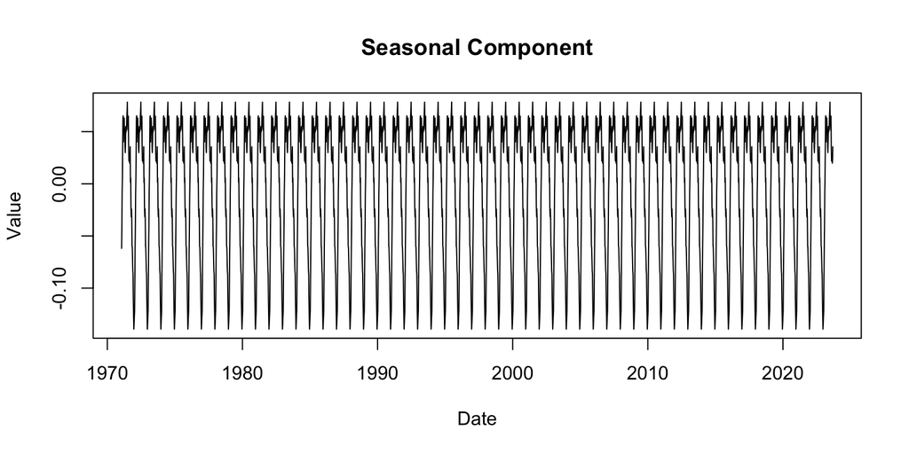

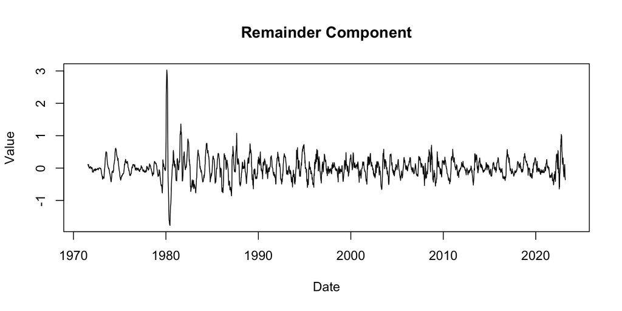

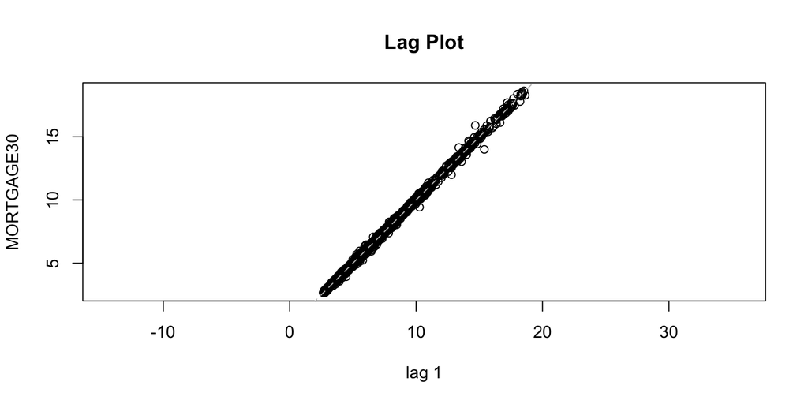

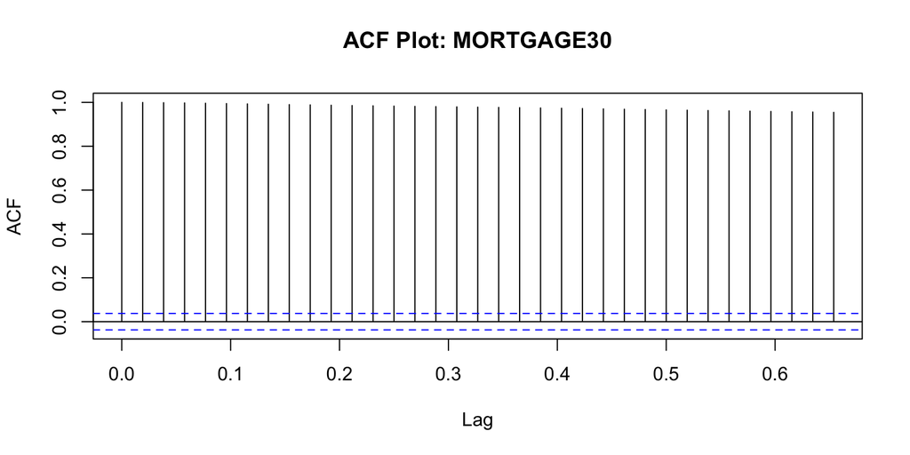

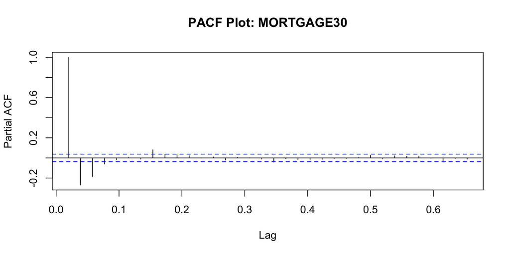

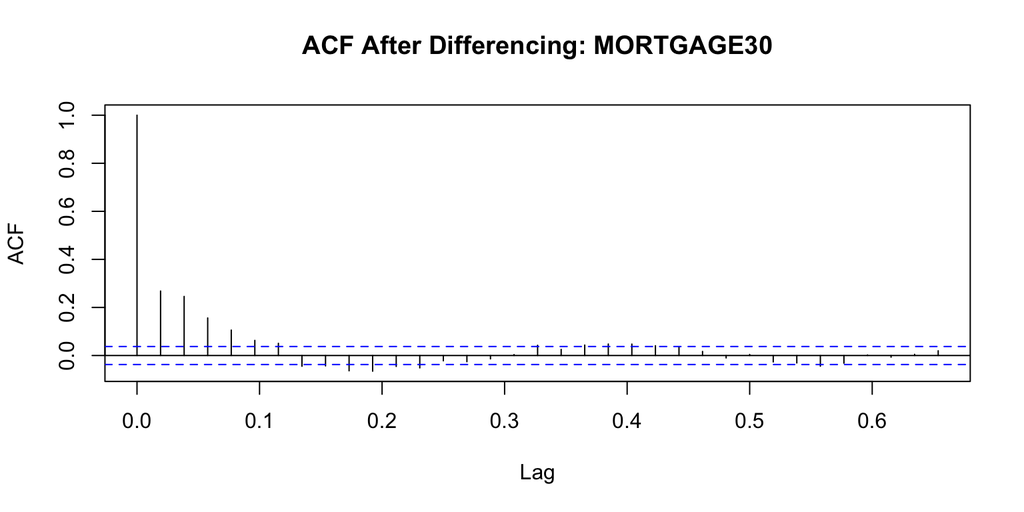

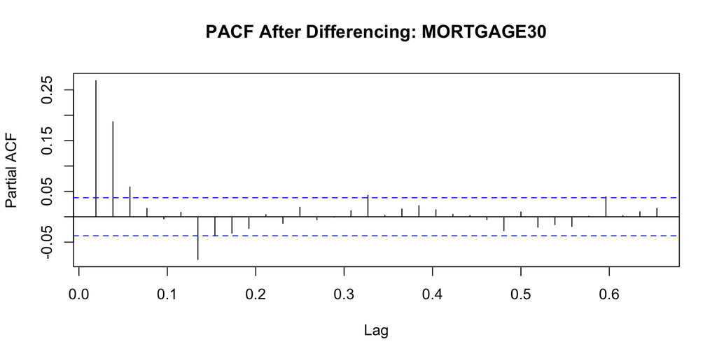

[output not shown]

**Unemployment Rate**

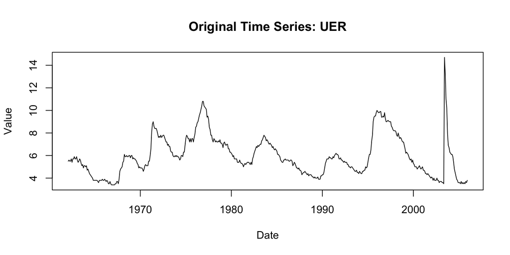

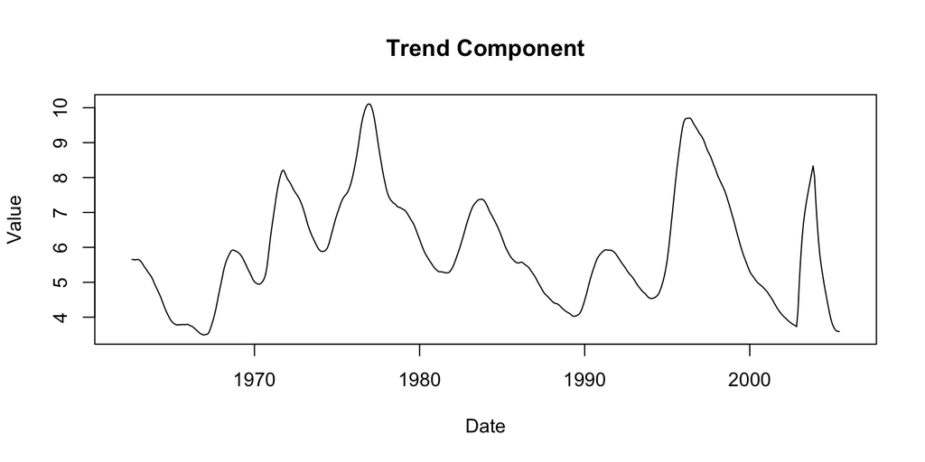

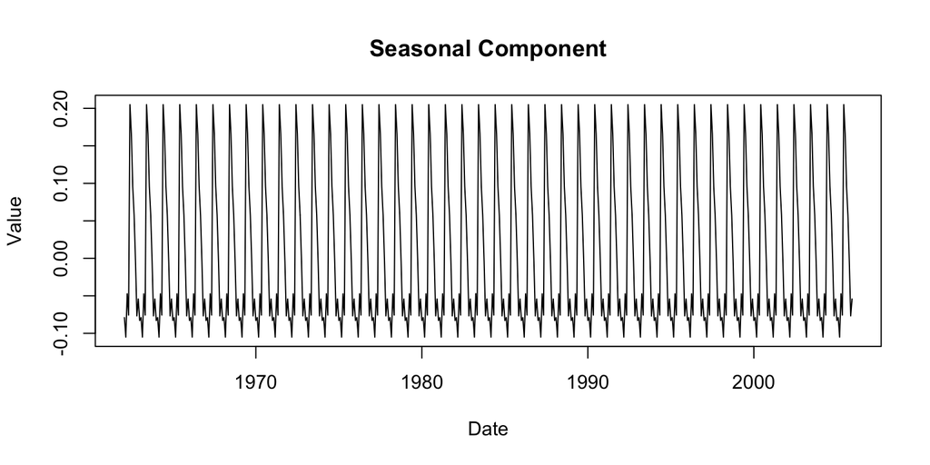

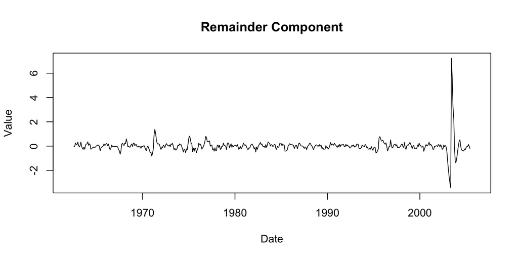

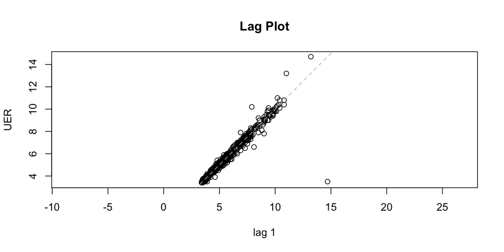

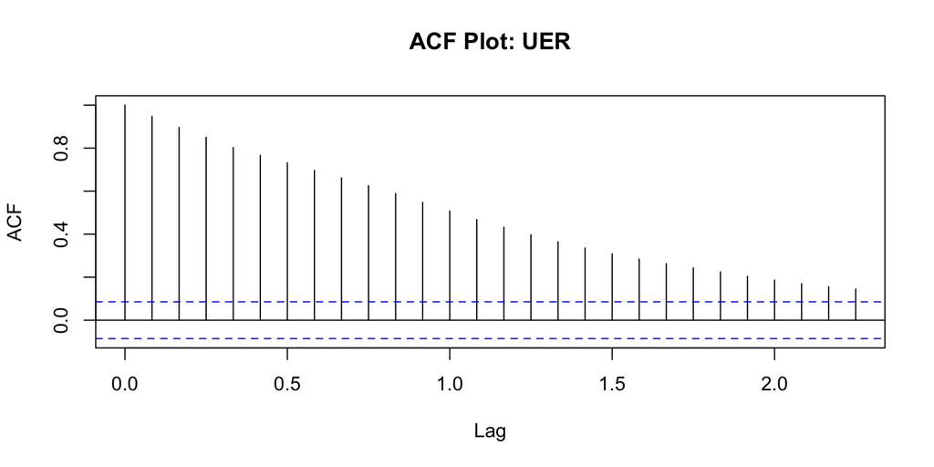

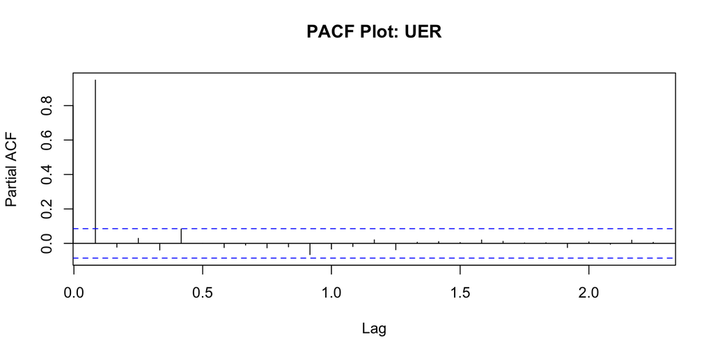

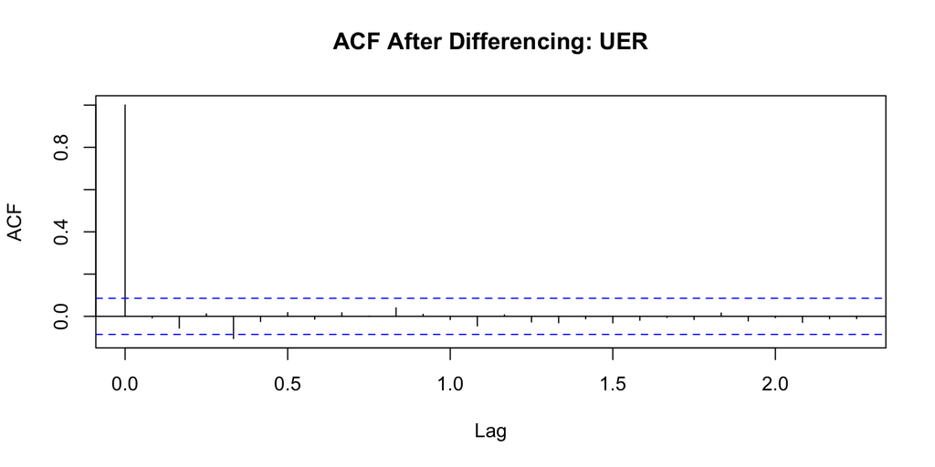

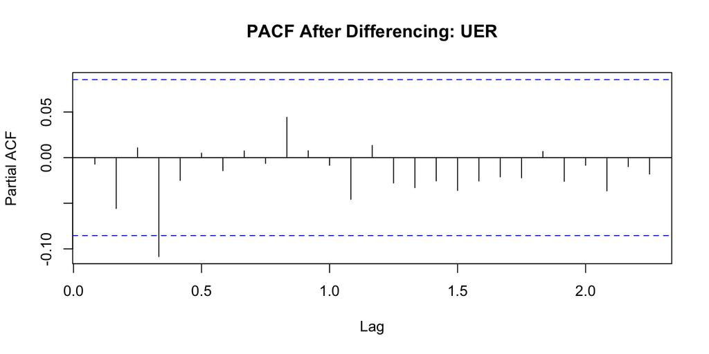

[output not shown]

## Moving Average Smoothing

**CPI**

The chart shows the Consumer Price Index (CPI) and its moving averages (MA10, MA50, MA100) all trending upwards, indicating long-term inflation growth. The MA10 closely follows the CPI’s short-term fluctuations, while the MA50 and MA100 smooth out these variations, lagging behind and highlighting the broader trend. The recent steep climb in the CPI suggests an acceleration in inflation not yet fully captured by the moving averages.

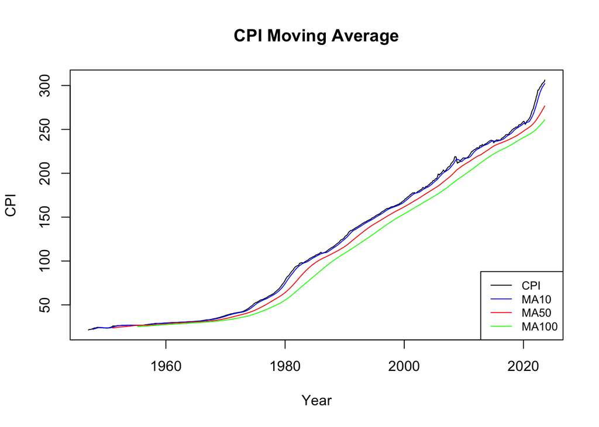

**GDP**

The chart illustrates the Gross Domestic Product (GDP) and its associated moving averages (MA10, MA50, MA100), all ascending, which signifies sustained economic growth. The MA10 is tracking the GDP’s immediate shifts, reflecting the economy’s short-term variations, whereas the MA50 and MA100 provide a more subdued perspective, trailing behind and emphasizing the long-term economic trend. The noticeable upward trajectory in the most recent GDP data points to a potential surge in economic activity, a detail that the longer-term moving averages have yet to fully incorporate.

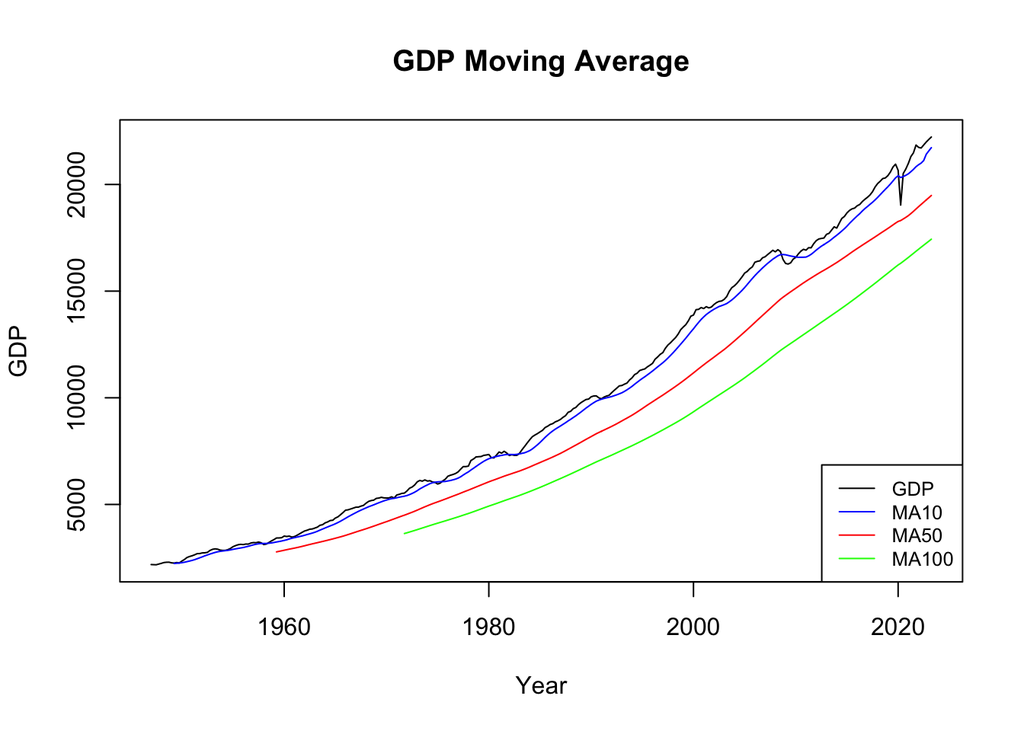

**US Dollar Index**

The chart shows the US Dollar Index with its moving averages (MA10, MA50, MA100), reflecting a volatile currency market. Short-term fluctuations are closely followed by MA10, while MA50 and MA100 smooth out these fluctuations to reveal more sustained trends. A notable peak and subsequent decline around 2020 are followed by a recovery, with recent trends suggesting an increase in the dollar’s value.

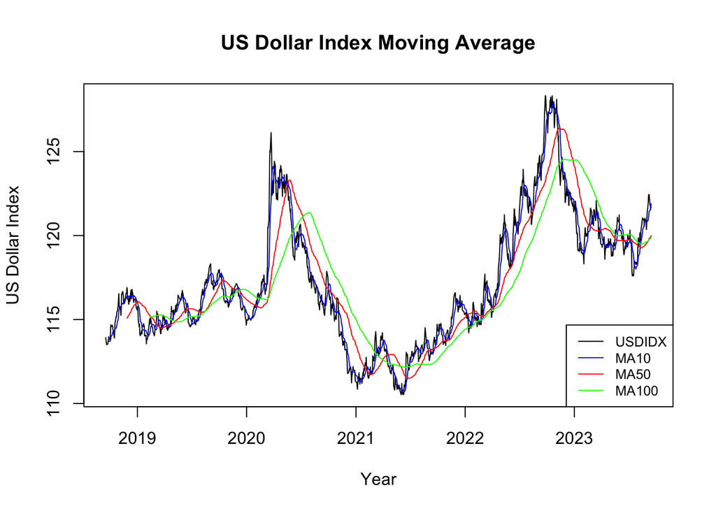

**30-Year Mortgage Rate**

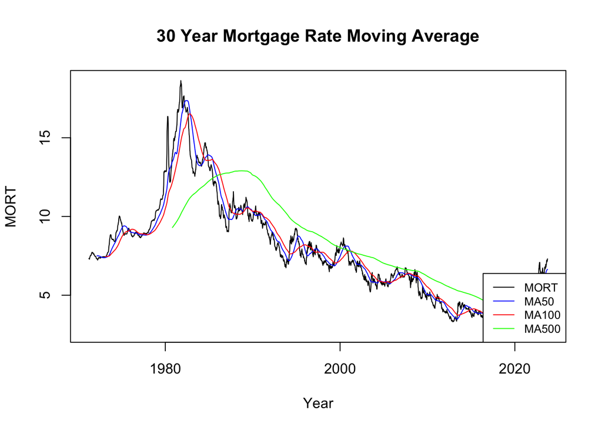

**Unemployment Rate**

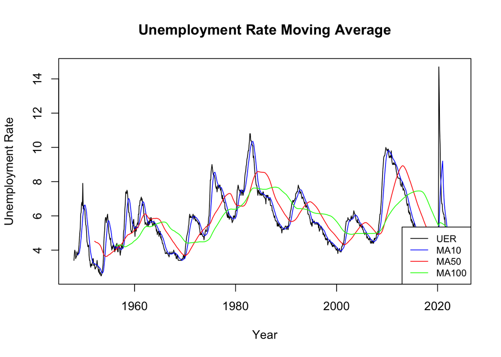